# HT2

Stefan Quintana, Sofía Escobar, Wilfredo Gallegos

2/16/2023

```
## Package 'mclust' version 6.0.0
```

## PROBLEMA 1

```r
datos<-read.csv("movies.csv")
set.seed(123)
datos<-datos[complete.cases(datos),]
summary(datos)
```

```
##        id             budget             genres            homePage
##  Min.   :     5   Min.   :        0   Length:3804        Length:3804
##  1st Qu.: 29807   1st Qu.:        0   Class :character   Class :character
##  Median :295644   Median :  3500000   Mode  :character   Mode  :character
##  Mean   :291505   Mean   : 24335422
##  3rd Qu.:489998   3rd Qu.: 30000000
##  Max.   :922162   Max.   :380000000
##  productionCompany  productionCompanyCountry productionCountry
##  Length:3804        Length:3804              Length:3804
##  Class :character   Class :character         Class :character
##  Mode  :character   Mode  :character         Mode  :character
##
##
##
##     revenue             runtime        video           director
##  Min.   :0.000e+00   Min.   :  0.0   Mode :logical   Length:3804
##  1st Qu.:0.000e+00   1st Qu.: 91.0   FALSE:3781      Class :character
##  Median :3.982e+06   Median :102.0   TRUE :23        Mode  :character
##  Mean   :7.859e+07   Mean   :103.3
##  3rd Qu.:7.009e+07   3rd Qu.:116.0
##  Max.   :2.847e+09   Max.   :400.0
##     actors          actorsPopularity   actorsCharacter    originalTitle
##  Length:3804        Length:3804        Length:3804        Length:3804
##  Class :character   Class :character   Class :character   Class :character
##  Mode  :character   Mode  :character   Mode  :character   Mode  :character
##
##
##
##     title           originalLanguage     popularity        releaseDate
##  Length:3804        Length:3804        Min.   :    6.781   Length:3804
##  Class :character   Class :character   1st Qu.:   15.774   Class :character
##  Mode  :character   Mode  :character   Median :   24.951   Mode  :character
##                                        Mean   :   68.185
##                                        3rd Qu.:   46.337
##                                        Max.   :11474.647
##     voteAvg         voteCount        genresAmount    productionCoAmount
##  Min.   : 1.300   Min.   :    1.0   Min.   : 0.000   Min.   : 0.000
##  1st Qu.: 6.100   1st Qu.:  173.8   1st Qu.: 2.000   1st Qu.: 2.000
##  Median : 6.600   Median :  680.5   Median : 3.000   Median : 3.000
##  Mean   : 6.616   Mean   : 1871.4   Mean   : 2.664   Mean   : 3.493
##  3rd Qu.: 7.200   3rd Qu.: 2051.0   3rd Qu.: 3.000   3rd Qu.: 5.000
##  Max.   :10.000   Max.   :30788.0   Max.   :16.000   Max.   :25.000
##  productionCountriesAmount  actorsAmount      castWomenAmount
##  Min.   : 0.000            Min.   :     0.0   Length:3804
##  1st Qu.: 1.000            1st Qu.:    14.0   Class :character
##  Median : 1.000            Median :    24.0   Mode  :character
##  Mean   : 1.708            Mean   :   685.7
##  3rd Qu.: 2.000            3rd Qu.:    41.0
##  Max.   :57.000            Max.   :784594.0
##  castMenAmount
##  Length:3804
##  Class :character
##  Mode  :character
##
##
##
```

### budget

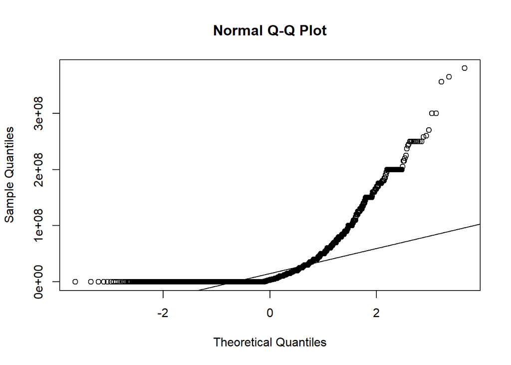

```
##
##  Lilliefors (Kolmogorov-Smirnov) normality test
##
## data:  datos$budget
## D = 0.28864, p-value < 2.2e-16
```

### revenue

[figure not shown]

```
##
##  Lilliefors (Kolmogorov-Smirnov) normality test
##
## data:  datos$revenue
## D = 0.33675, p-value < 2.2e-16
```

Basándose en la gráfica, donde se puede notar que los puntos se alejan de la recta teórica, podemos argumentar que los datos no respetan una distribución normal, lo cuál se confirma en el test Kolmogorov-Smirnov, donde se rechaza la hipótesis nula, por lo tanto, se concluye que los datos no provienen de una distribución normal.

### runtime

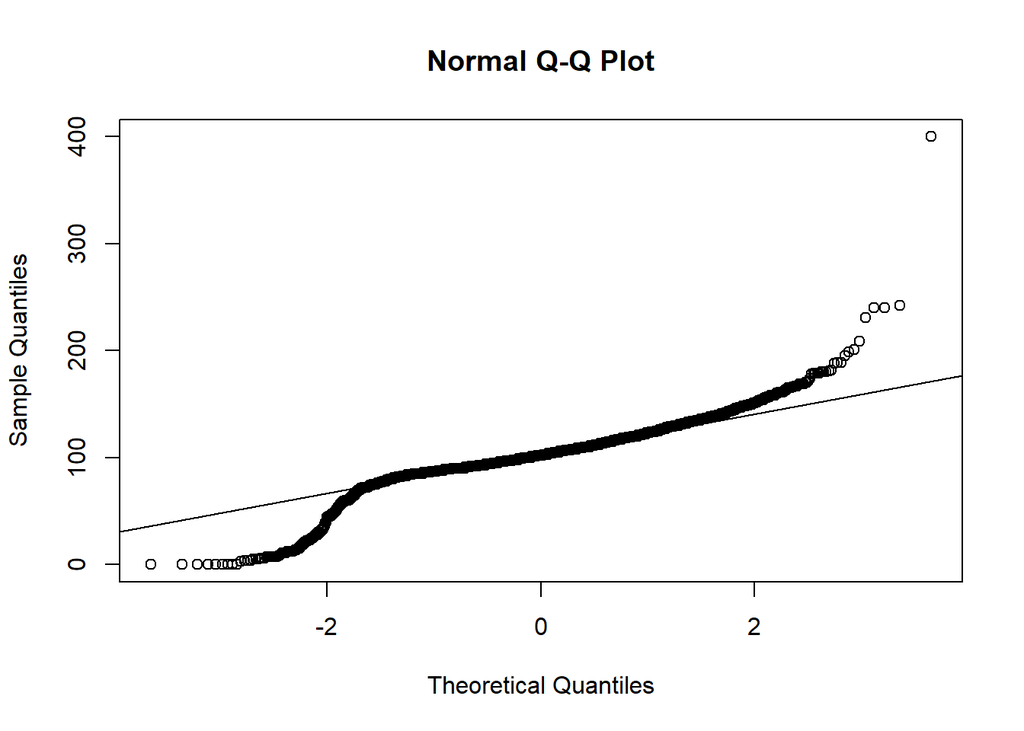

```
##
##  Lilliefors (Kolmogorov-Smirnov) normality test
##
## data:  datos$runtime
## D = 0.11209, p-value < 2.2e-16
```

Análogamente con el set de datos anterior, el valor p del test Kolmogorov-Smirnov hace que se rechace la hipótesis nula y se concluya que los datos no provienen de una distribución normal.

### popularity

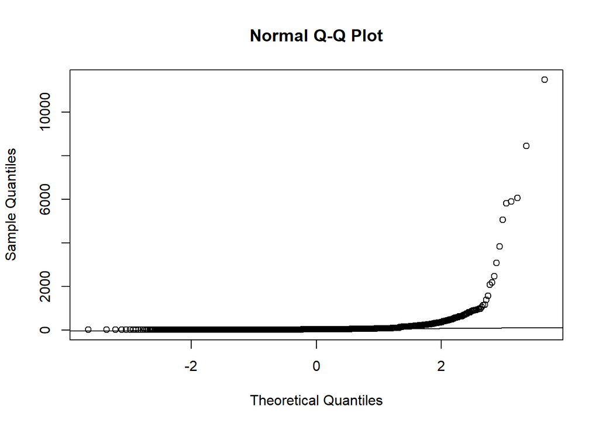

```
##
##  Lilliefors (Kolmogorov-Smirnov) normality test
##
## data:  datos$popularity
## D = 0.42564, p-value < 2.2e-16
```

El valor-p de el test Kolmogorov-Smirnov nos indica que se rechaza la hipótesis nula, por lo tanto, se concluye que los datos no provienen de una distribución normal.

### voteAvg

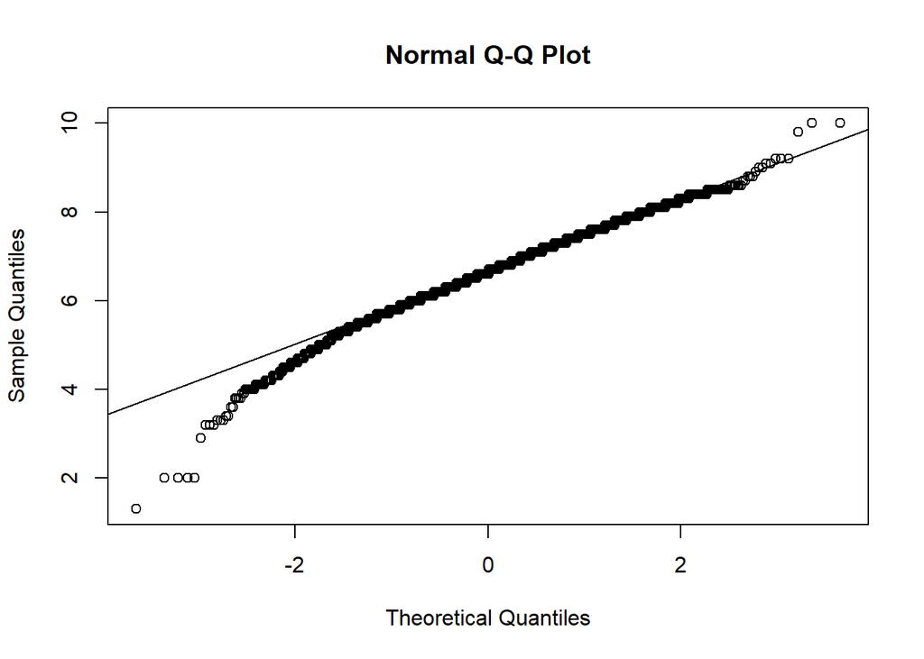

```
##
##  Lilliefors (Kolmogorov-Smirnov) normality test
##
## data:  datos$voteAvg
## D = 0.041883, p-value < 2.2e-16
```

El valor-p de el test Kolmogorov-Smirnov y la gráfica indican que los datos no respetan una distribución normal.

### voteCount

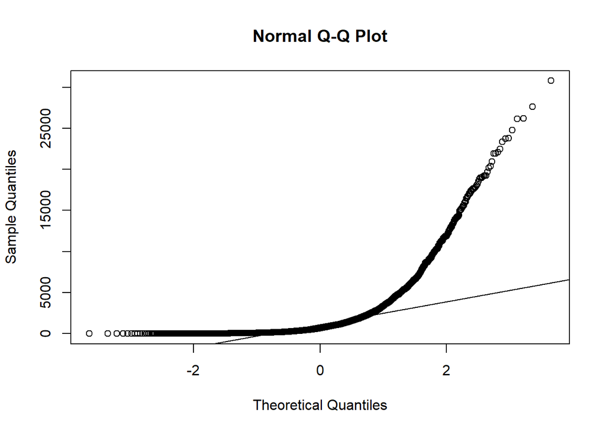

```
##
##  Lilliefors (Kolmogorov-Smirnov) normality test
##
## data:  datos$voteCount
## D = 0.27822, p-value < 2.2e-16
```

Nuevamente, el valor-p del test de Kolmogorov-Smirnov es menor a 0.05, por lo tanto, se rechaza la hipótesis nula y se argumenta que los datos no provienen de una distribución normal.

### genresAmount

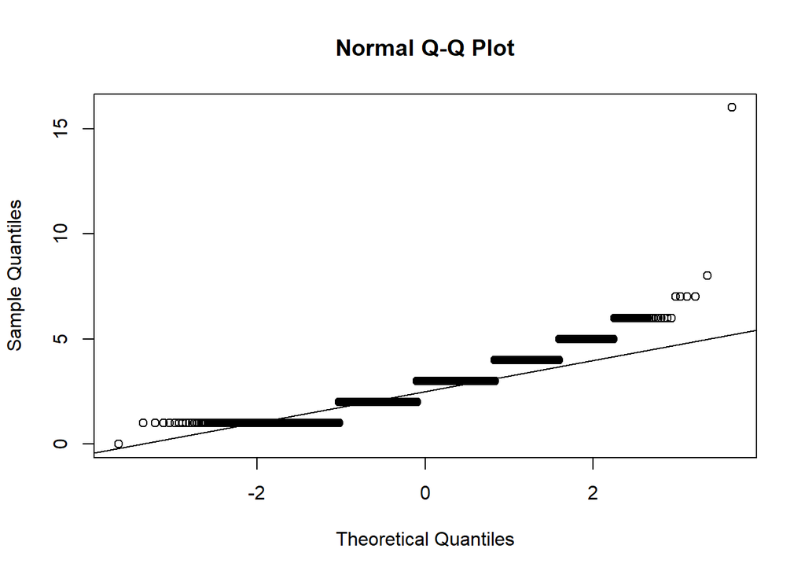

```
##
##  Lilliefors (Kolmogorov-Smirnov) normality test
##
## data:  datos$genresAmount
## D = 0.18043, p-value < 2.2e-16
```

Con un valor-p menor a 0.05 en el test Kolmogorov-Smirnov se rechaza la hipótesis nula y se concluye que los datos no provienen de una distribución normal, argumento que refuerza la gráfica.

### productionCoAomunt

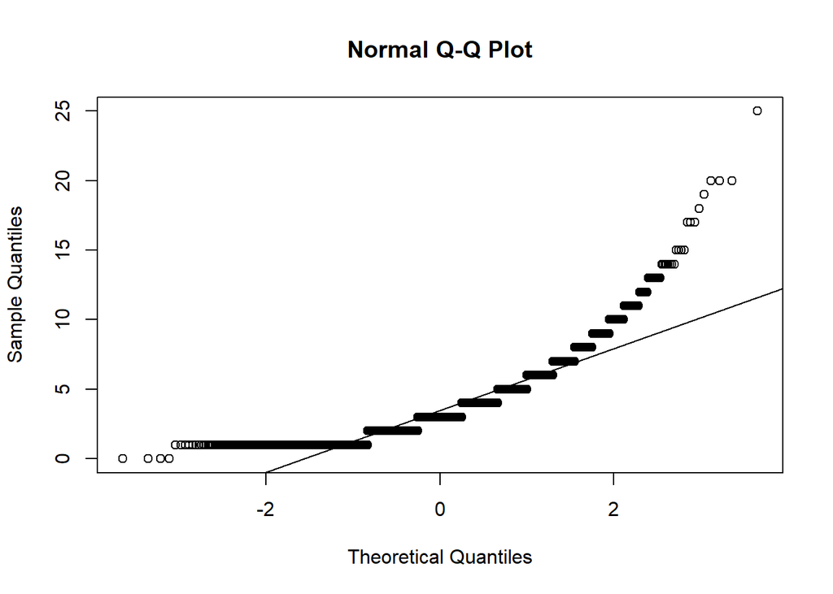

```
##
##  Lilliefors (Kolmogorov-Smirnov) normality test
##
## data:  datos$productionCoAmount
## D = 0.17897, p-value < 2.2e-16
```

El test Kolmogorov-Smirnov revela un valor-p menor a 0.05, además la gráfica nos muestra que los datos no se mantienen cercanos a la recta teórica en su totalidad, por lo tanto, se concluye que los datos no provienen de una distribución normal.

### productionCountriesAmount

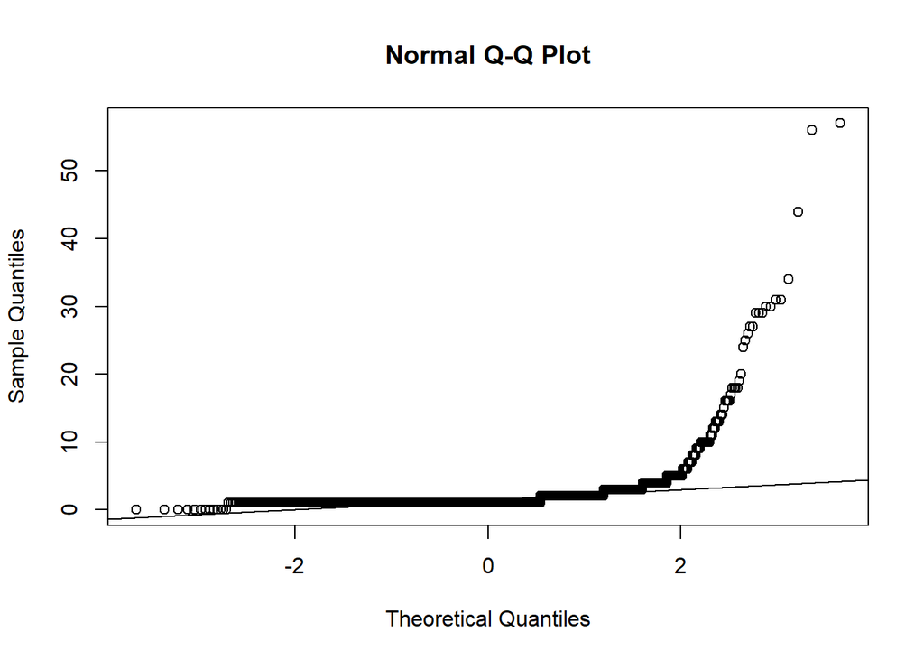

```
##
##  Lilliefors (Kolmogorov-Smirnov) normality test
##
## data:  datos$productionCountriesAmount
## D = 0.39031, p-value < 2.2e-16
```

Al observar la gráfica podemos notar que los datos no se mantienen cercanos a la recta teórica en su totalidad, además el test Kolmogorov-Smirnov nos da un valor-p el cuál nos hace rechazar la hipótesis nula, argumentando así, que los datos no provienen de una distribución normal.

### actorsAmount

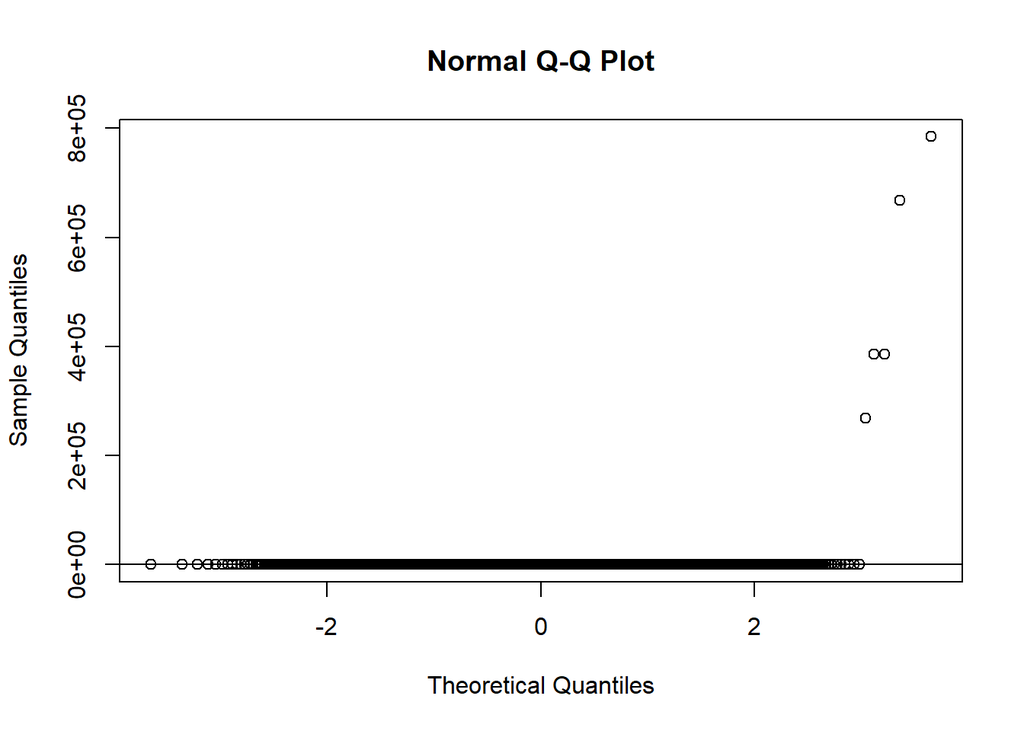

```
##
##  Lilliefors (Kolmogorov-Smirnov) normality test
##
## data:  datos$actorsAmount
## D = 0.50786, p-value < 2.2e-16
```

Debido a que se obtiene un valor-p menor a 0.05 en el test de Kolmogorov-Smirnov, se rechaza la hipótesis nula y se concluye que los datos no provienen de una distribución normal.

### castWomenAmount

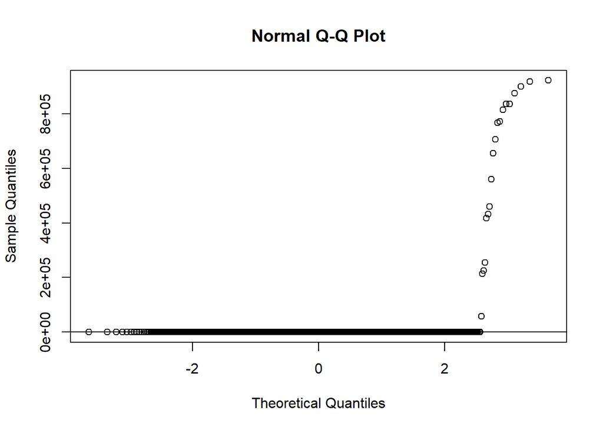

```
##
##  Lilliefors (Kolmogorov-Smirnov) normality test
##
## data:  d1
## D = 0.52002, p-value < 2.2e-16
```

Se puede notar en la gráfica que muchos de los datos no se mantienen en cercanía a la recta teórica, por lo tanto, se concluye que el set de datos no respeta una distribución normal, conclusión reforzada por el test Kolmogorov-Smirnov.

### castMenAmount

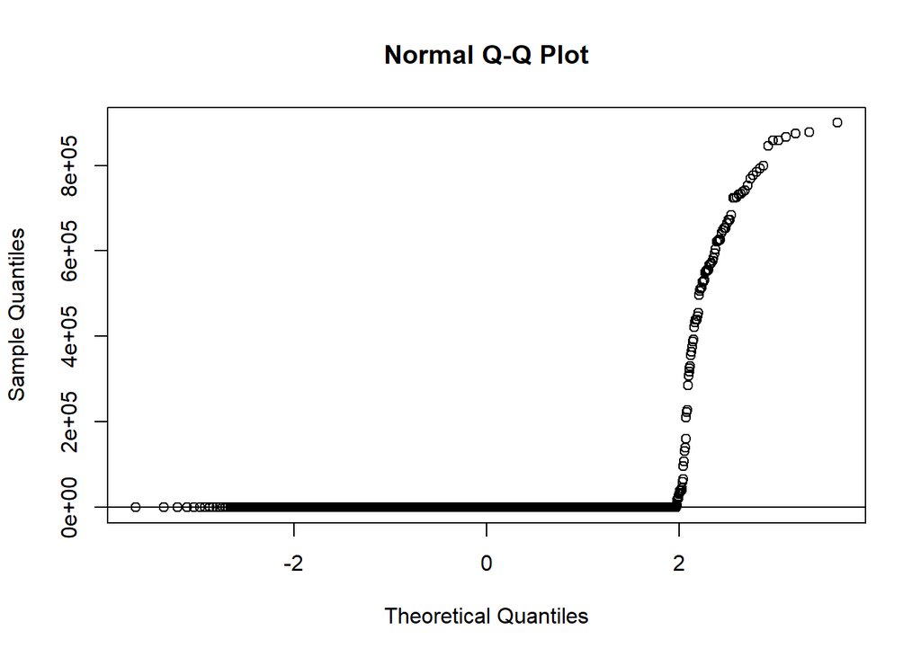

```
##
##  Lilliefors (Kolmogorov-Smirnov) normality test
##
## data:  d2
## D = 0.52985, p-value < 2.2e-16
```

Nuevamente, obtenemos una gráfica donde los valores no se mantienen cercanos a la recta teórica y un valor-p menor a 0.05 en el test Kolmogorov-Smirnov, lo cuál hace que se concluya que no hay normalidad en el set de datos.

En el análisis exploratorio realizado se determinó que las variables cuantitativas no respetaban una distribución normal. Por lo tanto, todas las variables son a tomar en cuenta en el proceso.

## PROBLEMA 2

```r
hopkins(datosCS)
```

```
## [1] 0.9999983
```

```r
#Matriz de distancia
datos_dist<- dist(datosCS)
```

Con un valor alejado a 0.5 se puede concluir que los datos no son aleatorios, por lo tanto, es adecuado el proceso de agrupamiento

```r
#knitr::opts_chunk$set(fig.width=12, fig.height=8)
#fviz_dist(datos_dist, show_labels = F)
```

## PROBLEMA 3

Determine cuál es el número de grupos a formar más adecuado para los datos que está trabajando. Haga una gráfica de codo y explique la razón de la elección de la cantidad de clústeres con la que trabajará.

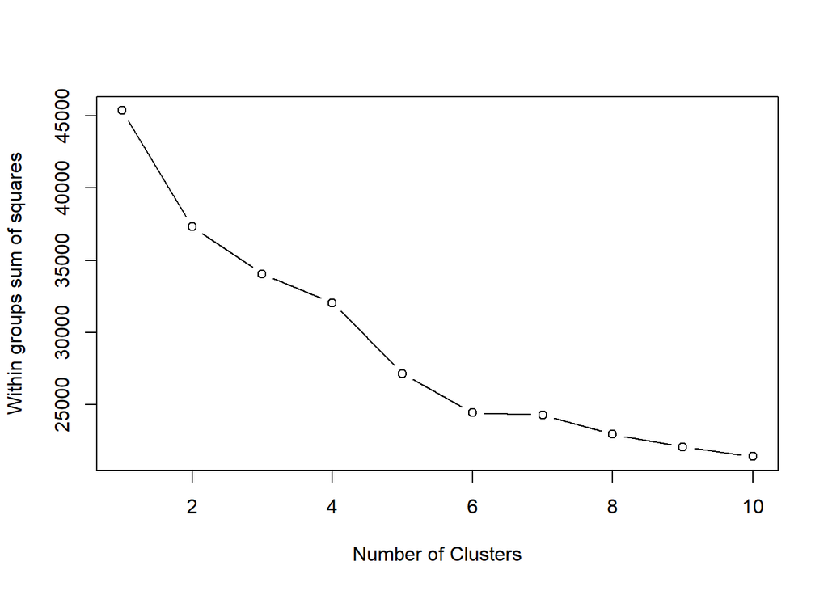

```r
wss=0
for (i in 1:10)
  wss[i] <- sum(kmeans(datosCS, centers=i)$withinss)

plot(1:10, wss, type="b", xlab="Number of Clusters",  ylab="Within groups sum of squares")
```

Podemos determinar la cantidad de grupos o clusters a través de un análisis para la gráfica generada por el método del codo. Podemos observar la particularidad del gráfico anterior que muestra un primer codo para la cantidad de grupos 3, y luego se genera otro segundo codo falso en la cantidad 6, se realizaron algoritmos como en el problema 4 para 6 grupos/clusters pero el agrupamiento no era uniforme, por lo que se decidió escoger agrupar los datos en 3 grupos, que es la cantidad de grupos con lo que se desarrollaron las siguientes preguntas.

## PROBLEMA 4

Utilice los algoritmos k-medias y clustering jerárquico para agrupar. Compare los resultados generados por cada uno.

### K-means

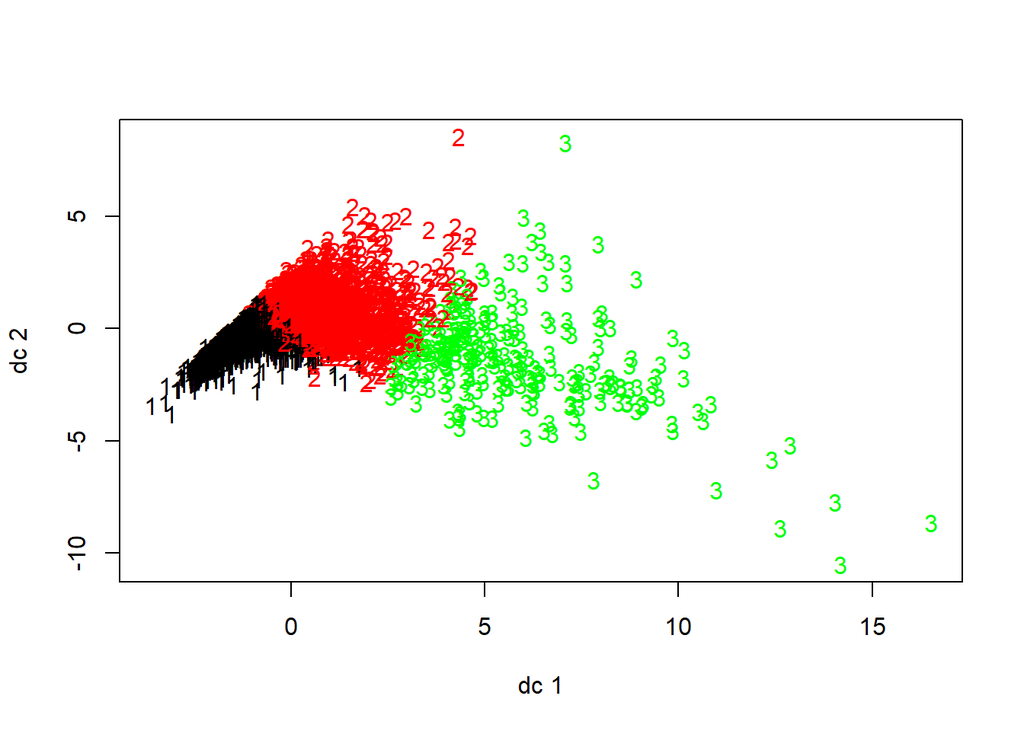

```r
km<-kmeans(datosCS,3,iter.max =1000)
#datos$grupo<-km$cluster
plotcluster(datosCS,km$cluster)
```

```r
#plotcluster(datosCS[,1:12],km$cluster)
```

Como se observa en el grafico generado para k-Means, el primer paso es escoger el numero de grupos K, en este caso fue 3 tal como se dejo claron en el problema anterior. A continuación se presenta otro gráfico para K-Means y poder observar de mejor manera las agrupaciones.

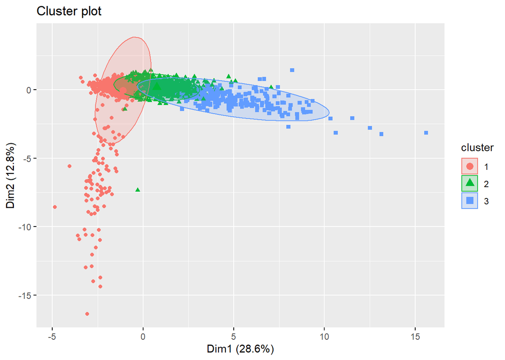

```r
fviz_cluster(km, data = datosCS,geom = "point", ellipse.type = "norm")
```

### Cluster jerarquico

A continuación se presenta el gráfico generado para el algoritmo de agrupación jerarquico.

```r
matriz_dist<- dist(datosCS)
hc<-hclust(datos_dist, method = "ward.D2") #Genera el clustering jerarquico de los datos
plot(hc, cex=0.5, axes=FALSE) #Genera el dendograma
cutree(hc, h = 3)
```

[output not shown]

[output cut: 459 more lines]

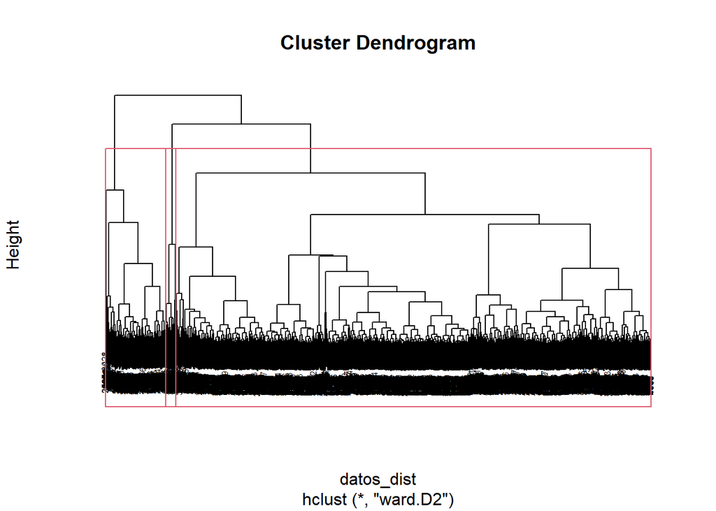

```r
rect.hclust(hc,k=3)
```

```r
groups<-cutree(hc,k=3) #corta el dendograma, determinando el grupo de cada fila
```

## PROBLEMA 5

El gráfico de la silueta de K-means sería el siguiente:

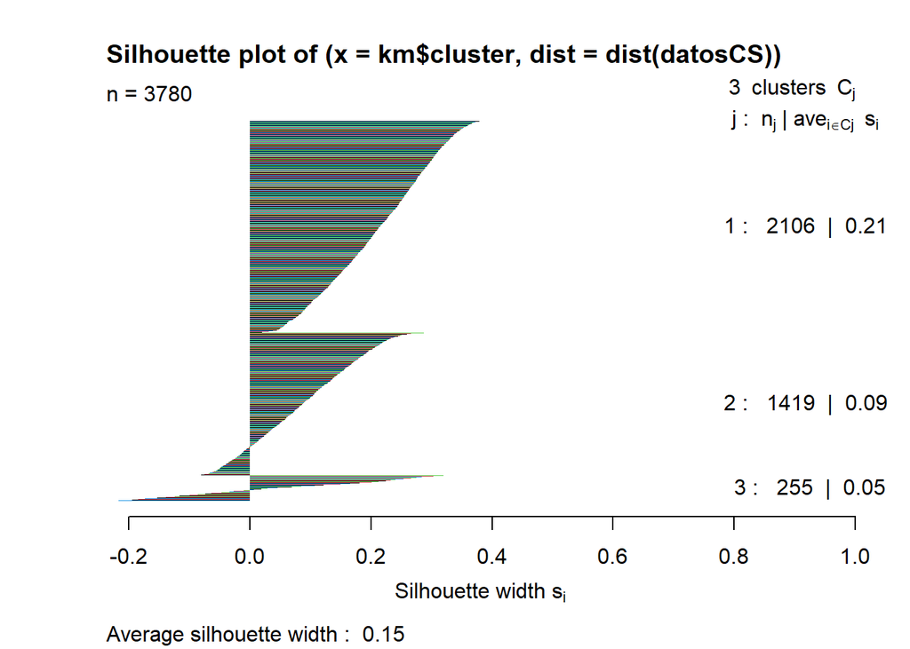

```r
silkm<-silhouette(km$cluster,dist(datosCS))
plot(silkm, cex.names=.4, col=1:4, border=NA)
```

```r
Kmean<-mean(silkm[,3])
```

Y el gráfico de la silueta de Jerargico sería:

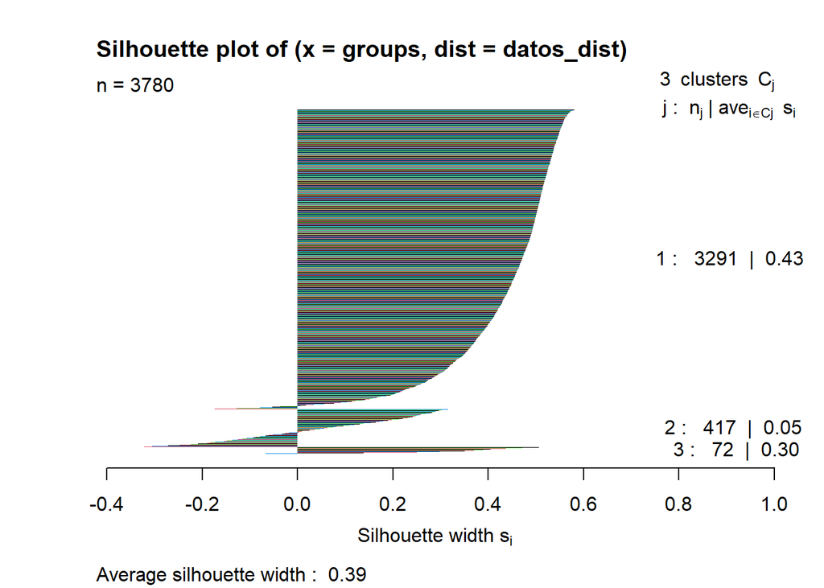

```r
silhc<-silhouette(groups,datos_dist)
plot(silhc, cex.names=.5, col=1:4, border = NA)
```

```r
Jerarquico<-mean(silhc[,3])
```

Al recopilar el promedio de los datos obtenemos:

```r
df <- data.frame(Algoritmo=c("K-mean", "Jerarquico"),
                Silueta=c(Kmean, Jerarquico))
df
```

```
##    Algoritmo   Silueta
## 1     K-mean 0.1534317
## 2 Jerarquico 0.3883915
```

## PROBLEMA 6

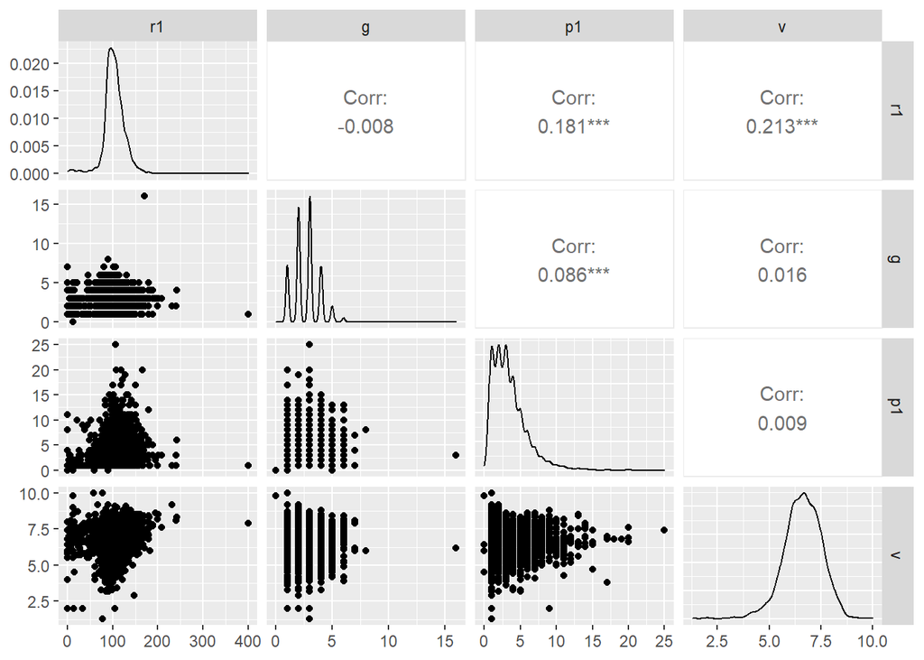

```r
library(GGally)
ggpairs(datosc,columns=c(4,5,6,9))
```